# Exploratory Data Analysis

David Angelo Brillantes (dsbrillantes@up.edu.ph)

November 2 - 8, 2020

# Setting Things Up

This notebook is where I perform exploratory data analysis (EDA) on publicly-available [**IMDB**](https://www.imdb.com/) Data (retrieved Nov. 3, 2020) after cleaning and writing the tables into an SQLite database file (see `./Scripts/00 Data Sourcing.R`). According to the website’s [**About**](https://help.imdb.com/article/imdb/general-information/what-is-imdb/G836CY29Z4SGNMK5?ref_=__seemr#) page,

> IMDb is the world’s most popular and authoritative source for movie, TV and celebrity content, designed to help fans explore the world of movies and shows and decide what to watch.  
> Our searchable database includes millions of movies, TV and entertainment programs and cast and crew members. We help you jog your memory about a movie, show, or person on the tip of your tongue, find the best movie or show to watch next, and empower you to share your entertainment knowledge and opinions with the world’s largest community of fans.

Now that we’re familiar with IMDB, we can now proceed with the EDA. For our purposes, we will be answering the following questions.

1. What is the highest rated movie in 2018?
2. Who was the most popular actor in 2018?
3. What is the longest runtime of a single movie? Aggregate runtime of a trilogy?
4. Have there been changes in trend in movie genres in the past 10 years?

The code chunk below sets up the environment where we declare directories, set options, and load libraries.

```r
# << Set Options >>
options(java.parameters = "-Xmx30g",
        scipen = 999999,
        dplyr.summarise.inform = FALSE)


# << Load Libraries >>
suppressWarnings({
  suppressPackageStartupMessages({
    library(DBI)
    library(fastmatch)
    library(lubridate)
    library(data.table)
    library(dplyr)
    library(tidyr)
    library(knitr)
    library(purrr)
    library(kableExtra)
    library(tidytable)
    library(ggplot2)
    library(scales)
    library(viridis)
    library(tidytext)
    library(stringr)
    library(stringi)
    library(stringdist)
    library(reticulate)
  })
})

# << Paths >>

# Home Folders
loc.main     <- "./"
loc.input    <- paste0(loc.main, "Input/")
loc.output   <- paste0(loc.main, "Output/")

# Data Marts
loc.imdb     <- paste0(loc.input, "Data/IMDB/")
loc.imdb_db  <- paste0(loc.imdb, "imdb_movies.sqlite")
loc.kaggle   <- paste0(loc.input, "Data/Kaggle/")

# << Utility Functions >>
pipe_message <- function(df, message = NULL, fill = 2, crayon_f = NULL) {

  # --- --- --- --- --- --- --- --- --- --- --- --- ---
  # --- For including messages in pipes
  # --- --- --- --- --- --- --- --- --- --- --- --- ---

  if (!is.null(message)) {
    if (!is.null(crayon_f)) message <- do.call(getExportedValue("crayon", crayon_f), list(message))
    cat(message, fill = fill)
  }
  return(df)
}

gcQuiet <- function(quiet = TRUE, ...) {

  # --- --- --- --- --- --- --- --- --- --- --- --- ---
  # --- Quiet version of gc()
  # --- --- --- --- --- --- --- --- --- --- --- --- ---

  if (quiet) invisible(gc()) else gc(...)
}
```

To load the data, we simply connect to the SQLite file and make SQL queries. The Tables and their fields are shown below ([more info](https://www.imdb.com/interfaces/)).

```r
# Establish Connection to SQLite DB
imdb_db   <- dbConnect(RSQLite::SQLite(), loc.imdb_db)

# List All Tables and Fields
imdb_tabs <- lapply(dbListTables(imdb_db), function(tab) {
    data.frame(Table = tab, Field = dbListFields(imdb_db, tab))
  }) %>%
  rbindlist() %>%
  summarise.(Fields = toString(Field), .by = Table)

kable(imdb_tabs, caption = "List of Fields for Each SQLite Table") %>%
  kable_styling(c("hover", "condensed", "responsive"))
```

List of Fields for Each SQLite Table

| Table | Fields |
| --- | --- |
| imdb_top250 | Rank, Title, ReleaseYear, IMDB_Rating, tconst, ReleaseDate, Plotline, Keywords, Budget, WW_Gross |
| name_basics | nconst, primaryName, birthYear, deathYear, knownForTitles, CastAgeYears, mainProfession, subProfession1, subProfession |
| title_aka | titleId, title, language, isOriginalTitle, country_name |
| title_basics | tconst, titleType, primaryTitle, isAdult, startYear, runtimeMinutes, mainGenre, subGenre1, subGenre2, tconst_int, NumGenres, FilmAgeYears |
| title_prin | tconst, ordering, nconst, category |
| title_rating | tconst, averageRating, numVotes |
| wiki_trilogies | SeriesId, Series, Entry_1, Entry_2, Entry_3 |

# What is the highest rated movie in 2018?

For this question, we can directly make use of the `title_basics` and `title_rating` tables, and joining them by the unique identifier for each movie title, `tconst`. IMDB uses a **weighted average** to compute the ratings according to the [FAQs](https://help.imdb.com/article/imdb/track-movies-tv/ratings-faq/G67Y87TFYYP6TWAV#).

```r
query.ratings.2018 <- "
    SELECT t_basics.primaryTitle AS Title,
           t_basics.mainGenre AS Genre,
           t_rating.averageRating AS Rating,
           t_rating.numVotes AS Votes
      FROM title_basics AS t_basics
INNER JOIN title_rating AS t_rating ON t_basics.tconst = t_rating.tconst
     WHERE t_basics.startYear = 2018
  ORDER BY t_rating.averageRating desc
"

ratings_2018 <- dbGetQuery(imdb_db, query.ratings.2018)
kable(ratings_2018[1:5,], caption = "Five Highest Rated Movies of 2018") %>%
  kable_styling(c("hover", "condensed", "responsive"))
```

Five Highest Rated Movies of 2018

| Title | Genre | Rating | Votes |
| --- | --- | --- | --- |
| Peerless Hero | Action | 10 | 5 |
| Alien Invasion | Sci-Fi | 10 | 5 |
| Once Upon a Time in the Wild | Comedy | 10 | 6 |
| The Straight and Narrow | Drama | 10 | 6 |
| Foster Sin | Drama | 10 | 6 |

We can see that there are movies that were able to get a perfect score of 10 in 2018. However, the above table does not take into account the raw number of votes that the movie had, which may be more useful to us. To incorporate this, we create a new variable, `Popularity` that serves as an index. It is calculated by multiplying the average rating with the number of votes. We can then split the dataset into two: movies that are below the median `Popularity` and those above it. Finally, we look at the top rated movies within those two groups. To further weed out the movies with a small number of votes, we filter the dataset to those with a number of votes above the median number of votes.

```r
# Create Popularity Index & Filter by # of Votes
ratings_2018_pop     <- ratings_2018 %>% mutate.(Popularity = Votes*Rating) %>% filter.(Votes >= median(Votes))
ratings_2018_pop_med <- median(ratings_2018_pop$Popularity)

# Split Data
ratings_2018_pop_hi <- filter.(ratings_2018_pop, ratings_2018_pop$Popularity >= ratings_2018_pop_med) %>% slice_max.(Rating, n = 3)
ratings_2018_pop_lo <- filter.(ratings_2018_pop, ratings_2018_pop$Popularity <  ratings_2018_pop_med) %>% slice_max.(Rating, n = 3)

kable(bind_rows.(ratings_2018_pop_hi, ratings_2018_pop_lo),
      caption = "Three Highest Rated Movies of 2018 by Popularity",
      format.args = list(big.mark = ",")) %>%
  kable_styling(c("hover", "condensed", "responsive")) %>%
  pack_rows("High Popularity", 1, 3) %>%
  pack_rows("Low Popularity", 4, 6)
```

Three Highest Rated Movies of 2018 by Popularity

| Title | Genre | Rating | Votes | Popularity |
| --- | --- | --- | --- | --- |
| **High Popularity** |  |  |  |  |
| The Nagano Tapes: Rewound, Replayed & Reviewed | Documentary | 9.3 | 221 | 2,055.3 |
| The Transcendents | Music | 9.2 | 1,456 | 13,395.2 |
| Eghantham | Drama | 9.2 | 644 | 5,924.8 |
| **Low Popularity** |  |  |  |  |
| Life: Amidral | Drama | 9.7 | 70 | 679.0 |
| Filthy Frank Final Full Lore Movie | Comedy | 9.6 | 112 | 1,075.2 |
| Manry at Sea: In the Wake of a Dream | Documentary | 9.5 | 75 | 712.5 |

It’s interesting to see that the highest rated films are documentaries and dramas. While we were able to incorporate the new `Popularity` index into this question, the resulting movies are still relatively unknown with a small number of votes especially considering the distribution of the votes, being skewed to the right by very popular movies.

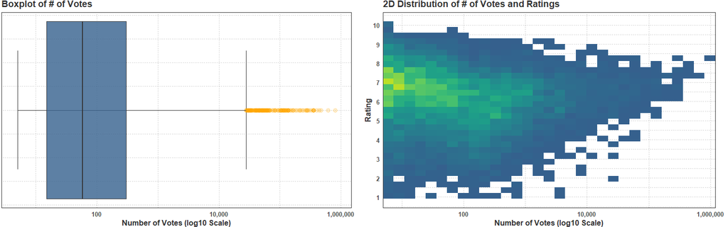

Another approach to this question is to use the same definition that IMDB uses in curating their **Top Rated Movies** list, which shows the top rated 250 movies. This is different from the weighted average used to get each film’s rating in that the “formula provides a true ‘Bayesian estimate’, which takes into account the number of votes each title has received, minimum votes required to be on the list, and the mean vote for all titles.” The formula is given below,

$$\text{Top 250 Rating} = (\frac{v}{v+m}\cdot R)\ +\ (\frac{m}{v+m}\cdot C)$$

Where

- $ v $ is the number of votes for the movie
- $ m $ is minimum votes required to be listed in the Top Rated list (currently 25,000)
- $ R $ is the average rating of the movie, and
- $ C $ is the mean vote across all titles

We now compute the ratings using this new formula. The only pre-filtering we do is to consider only movies with at least 25,000 votes.

```r
# Create Top 250 Rating
ratings_2018_top     <- ratings_2018 %>%
  filter.(Votes >= 25000) %>%
  mutate.(`Top Rating` = (Rating*Votes/(Votes + 25000)) + (mean(Rating)*25000/(Votes + 25000)),
          Popularity = Votes*Rating)
ratings_2018_top_med <- median(ratings_2018_top$Popularity)

# Split Data
ratings_2018_top_hi <- filter.(ratings_2018_top, ratings_2018_top$Popularity >= ratings_2018_top_med) %>% slice_max.(`Top Rating`, n = 3)
ratings_2018_top_lo <- filter.(ratings_2018_top, ratings_2018_top$Popularity <  ratings_2018_top_med) %>% slice_max.(`Top Rating`, n = 3)

kable(bind_rows.(ratings_2018_top_hi, ratings_2018_top_lo),
      caption = "Three Highest Top Rated Movies of 2018 by Popularity",
      format.args = list(big.mark = ",")) %>%
  kable_styling(c("hover", "condensed", "responsive")) %>%
  column_spec(5, background = "gold") %>%
  pack_rows("High Popularity", 1, 3) %>%
  pack_rows("Low Popularity", 4, 6)
```

Three Highest Top Rated Movies of 2018 by Popularity

| Title | Genre | Rating | Votes | Top Rating | Popularity |
| --- | --- | --- | --- | --- | --- |
| **High Popularity** |  |  |  |  |  |
| Avengers: Infinity War | Action | 8.4 | 809,261 | 8.345605 | 6,797,792.4 |
| Spider-Man: Into the Spider-Verse | Action | 8.4 | 347,298 | 8.278111 | 2,917,303.2 |
| Green Book | Biography | 8.2 | 351,834 | 8.092846 | 2,885,038.8 |
| **Low Popularity** |  |  |  |  |  |
| K.G.F: Chapter 1 | Action | 8.2 | 32,961 | 7.503338 | 270,280.2 |
| They Shall Not Grow Old | Documentary | 8.3 | 27,838 | 7.488478 | 231,055.4 |
| Tumbbad | Drama | 8.3 | 25,570 | 7.452082 | 212,231.0 |

Thus, the highest rated movie of 2018 is **Avengers: Infinity War**.

# Who was the most popular actor in 2018?

For this question, we can directly make use of the `title_prin` and `name_basics` tables. We also look at both actors and actresses who assumed the leading roles in their films. There are many ways to measure actor/actress popularity. Some of these are:

- Number of pageviews to profile
- Number of listed credits
- Frequency of appearance in user search queries
- Popularity of projects

The user data used for the above and in other measures are not readily available in the datasets that we have. Instead, our next best bet is to make use of movie data and use ratings and votes as proxies for popularity wherein intuition tells us that the more popular a movie was, the more likely the actor/actress was given the spotlight. For this question, we will only look at films released in 2018.

```r
query.leads.2018 <- "
    SELECT t_basics.*,
           t_prins.ordering,
           t_prins.nconst,
           t_prins.category,
           n_basics.primaryName AS Name,
           n_basics.mainProfession,
           2018 - n_basics.birthYear AS FilmAgeYears
      FROM title_prin AS t_prins
INNER JOIN name_basics AS n_basics ON t_prins.nconst = n_basics.nconst
INNER JOIN (    SELECT t_basics.tconst,
                       t_basics.primaryTitle AS Title,
                       t_basics.mainGenre AS Genre,
                       t_rating.averageRating AS Rating,
                       t_rating.numVotes AS Votes
                  FROM title_basics AS t_basics
            INNER JOIN title_rating AS t_rating ON t_basics.tconst = t_rating.tconst
                 WHERE t_basics.startYear = 2018) AS t_basics ON t_prins.tconst = t_basics.tconst
"

leads_2018 <- dbGetQuery(imdb_db, query.leads.2018) %>%

  # Filter to Films where they were Lead Actors/Actresses
  filter.(stri_detect_regex(category, "actor|actress")
        & stri_detect_regex(mainProfession, "actor|actress")) %>%
  filter.(ordering == min(ordering), .by = tconst) %>%
  mutate(Category = str_to_title(category)) %>%
  select.(-mainProfession, -ordering, -category)

kable(leads_2018[1:10, c("Title", "Name", "Category")],
      caption = "First Ten Lead Actors/Actresses in Movies Released in 2018") %>%
  kable_styling(c("hover", "condensed", "responsive"))
```

First Ten Lead Actors/Actresses in Movies Released in 2018

| Title | Name | Category |
| --- | --- | --- |
| The Other Side of the Wind | John Huston | Actor |
| Housesitter: The Night They Saved Siegfried's Brain | Stephen James Carver | Actor |
| Heaven & Hell | Cheryl M. Lynn | Actress |
| To Chase a Million | Richard Bradford | Actor |
| My Land | Saswata Chatterjee | Actor |
| Fahrenheit 451 | Michael B. Jordan | Actor |
| Nappily Ever After | Sanaa Lathan | Actress |
| A Million Little Pieces | Aaron Taylor-Johnson | Actor |
| The Queen of Sheba Meets the Atom Man | Taylor Mead | Actor |
| The Dirt | Douglas Booth | Actor |

In creating the `Spotlight` index, we make use of the `Popularity` column we created for each movie earlier. From there, we can summarize these by Actor/Actress. We divide `Popularity` by the number of movies he/she was in so we can roughly account for how spread out his/her popularity was garnered across his/her work.

```r
leads_2018_top <- leads_2018 %>%
  mutate.(Popularity = Votes*Rating) %>%
  summarise.(Spotlight = sum(Popularity)/n_distinct(tconst),
             Titles = toString(Title), .by = c(Name, Category)) %>%
  slice_max.(order_by = Spotlight, n = 5, .by = Category)

kable(leads_2018_top[,c("Name", "Titles", "Spotlight")],
      caption = "Five Most Popular Actors/Actresses in Movies released in 2018",
      format.args = list(big.mark = ",")) %>%
  kable_styling(c("hover", "condensed", "responsive")) %>%
  column_spec(3, background = "gold") %>%
  pack_rows("Actor", 1, 5) %>%
  pack_rows("Actress", 6, 10)
```

Five Most Popular Actors/Actresses in Movies released in 2018

| Name | Titles | Spotlight |
| --- | --- | --- |
| **Actor** |  |  |
| Robert Downey Jr. | Avengers: Infinity War | 6,797,792 |
| Chadwick Boseman | Black Panther | 4,470,396 |
| Ryan Reynolds | Deadpool 2 | 3,593,675 |
| Rami Malek | Bohemian Rhapsody | 3,511,472 |
| Shameik Moore | Spider-Man: Into the Spider-Verse | 2,917,303 |
| **Actress** |  |  |
| Emily Blunt | Mary Poppins Returns, A Quiet Place | 1,742,585 |
| Toni Collette | Hereditary | 1,676,730 |
| Olivia Colman | The Favourite | 1,250,108 |
| Cate Blanchett | Ocean's 8 | 1,226,598 |
| Jennifer Lawrence | Red Sparrow | 1,063,682 |

Thus, the most popular actor and actress in 2018 were **Robert Downey Jr.** and **Emily Blunt**. The [Top 10 Stars](https://www.businesswire.com/news/home/20181204005100/en/IMDb-Announces-the-Top-10-Stars-and-Top-10-Breakout-Stars-of-2018-as-Determined-by-Page-Views) list released by IMDB in 2018 is noticeably different as it is based on pageviews.

# What is the longest runtime of a single movie?

For this question, we can look at `runtimeMinutes` from the `title_basics` table.

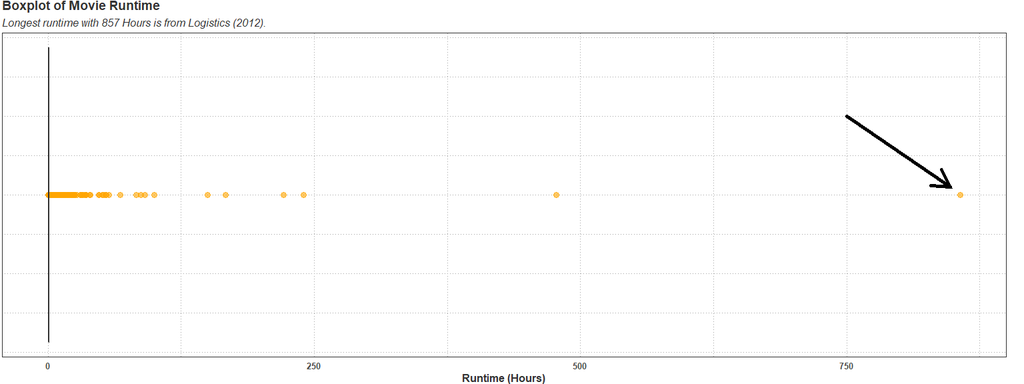

The movie with the single longest runtime is **Logistics**, an 857-hour (or 35-day) long documentary and Swedish experimental art film conceived and created by Erika Magnusson and Daniel Andersson. To get a better look of the distribution of runtimes, we can try to keep only movies that are at most 3 hours long.

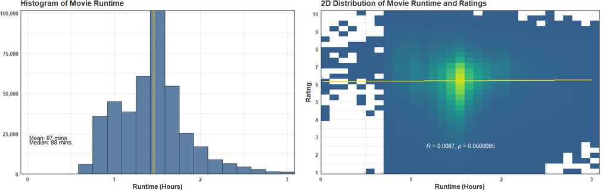

We can see that most of the movies have a runtime between 1 to 2 hours. The 2D plot also shows that there is no correlation between the runtime and the rating of the movie.

# What is the longest aggregate runtime of a trilogy?

Identifying movies as being part of a trilogy was a challenge in that the IMDB data alone is unable to do so. We thus scrape data from a Wikipedia **[article]**(https://en.wikipedia.org/wiki/List_of_feature_film_series_with_three_entries) that contains a list of film series with three entries. After cleaning the data, it was inserted as a table into the SQLite file. The next step is to attach the ratings from our IMDB data. As there is no clear way to match entries, we make use of the titles to do our string matching.

```r
trilogies <- dbGetQuery(imdb_db, "SELECT * FROM wiki_trilogies")

# First Attempt at Attaching Runtimes
trilogies_try1 <- trilogies %>%
  pivot_longer.(cols = c("Entry_1", "Entry_2", "Entry_3"),
                names_to = "EntryNum",
                values_to = "Title") %>%
  arrange(as.numeric(SeriesId)) %>%

  # Clean Data
  mutate.(Year = stri_extract_last(Title, regex = "\\(\\d{4}.*\\)"),
          Year = stri_replace_all_regex(Year, "\\(|\\)|[[:alpha:][:punct:]]", ""),
          Year = as.integer(str_trim(word(Year, 1))),
          Title = stri_replace_all_regex(Title, "\\*+|\\(.{1,2}\\)|\\(\\d{4}\\)", ""),
          Title = stri_replace_all_regex(Title, "\\[.*\\]", ""),
          TitleAKA = stri_extract_all_regex(Title, "\\(aka.*\\)"),
          TitleAKA = stri_replace_all_regex(TitleAKA, "\\(|aka|\\)", ""),
          TitleAKA = str_trim(str_squish(TitleAKA)),
          Title = str_split_fixed(Title, "\\(aka", n = 2)[,1],
          Title = stri_replace_all_regex(Title, "\\(.*\\)", ""),
          Title = str_trim(str_squish(Title))) %>%

  # Join with Runtime Data
  left_join.(runtime[,c("tconst", "Title", "Year")], by = c("Title", "Year"))

kable(trilogies_try1[1:9],
      caption = "First Attempt at Matching") %>%
  kable_styling(c("hover", "condensed", "responsive")) %>%
  column_spec(7, background = "gold")
```

First Attempt at Matching

| SeriesId | Series | EntryNum | Title | Year | TitleAKA | tconst |
| --- | --- | --- | --- | --- | --- | --- |
| 1 | 9½ Weeks | Entry_1 | 9½ Weeks | 1986 | NA | tt0091635 |
| 1 | 9½ Weeks | Entry_2 | Love in Paris | 1997 | NA | NA |
| 1 | 9½ Weeks | Entry_3 | The First 9½ Weeks | 1998 | NA | NA |
| 2 | 12 Rounds | Entry_1 | 12 Rounds | 2009 | NA | tt1160368 |
| 2 | 12 Rounds | Entry_2 | 12 Rounds 2: Reloaded | 2013 | NA | tt2317524 |
| 2 | 12 Rounds | Entry_3 | 12 Rounds 3: Lockdown | 2015 | NA | tt3957956 |
| 3 | 2012 | Entry_1 | 2012: Doomsday | 2008 | NA | NA |
| 3 | 2012 | Entry_2 | 2012: Supernova | 2009 | NA | NA |
| 3 | 2012 | Entry_3 | 2012: Ice Age | 2011 | NA | NA |

The first attempt simply matches by both the title and year of release. As we can see, not all entries from Wikipedia were successfully matched as some `tconst` are `NULL`. We thus have to consider the following issues that cannot be adequately covered by this first attempt:

- Small differences in title formats
- Small inconsistencies in release year
- Titles within a series are often very similar to each other
- We’re using IMDB `primaryTitle` which could be different from Wikipedia
- We’re only considering IMDB titles of type `movie` and `tvMovie`
- We’ve filtered the `runtime` table to those that have non-null `Runtime`

For these reasons, a more involved approach is needed:

- We measure **String Similarity** using the available algorithms
  - We make use of both the [Levenshtein](https://en.wikipedia.org/wiki/Levenshtein_distance) (LV) distance and the full [Damerau-Levenshtein](https://en.wikipedia.org/wiki/Damerau%E2%80%93Levenshtein_distance) (DL) distance methods as they are appropriate to the operations that are relevant to movie titles: insertions, deletions or substitutions of a single character, or transposition of two adjacent characters (for DL only)
  - We then set thresholds to consider as a valid match
  - For the lower thresholds, we try to incorporate the distance between the years where we allot a maximum discrepancy of 2 year
  - We also try if normalizing the strings to an extent can help, such as by:
    - Removing whitespaces
    - Change to all uppercase
    - change Roman numerals to Arabic
- Aside from the already existing `movie` and `tvMovie` titles, we also include `video` titles to complete the list as much as possible
- If amenable, we also try to scrape missing data on runtimes

First, let’s create the functions needed.

```r
# Normalizing Function
title_normalize <- function(t) {
  t <- t %>%
    toupper() %>%
    str_replace("\\b[IVX]+\\b", function(x) as.numeric(as.roman(x))) %>%
    stri_replace_all_fixed(" ", "")

  return(t)
}

# Matching Function
title_match <- function(t, threshold = 0.8, method = "lv", year = NULL,
                        top_res = 2, year_threshold = 1,
                        target_title = "primaryTitle_target",
                        alt_title = c("originalTitle_target", "AKAtitle_target")) {

  cat("\n>>> Trying", t)
  if (is.na(year)) year <- NULL

  for (use in c(target_title, alt_title)) {
    use_ <- str_replace(use, "_target", "")
    res  <- stringsim(t, target[[use]], method = method)

    # Main --- --- --- --- --- --- ---
    if (max(res, na.rm = T) >= threshold) {

      max_res <- unique(order(res, decreasing = T))[1:top_res]

      # Second --- --- --- --- --- --- ---
      if (!is.null(year)) {
        # Innermost --- --- --- --- --- --- ---
        max_years <- target$startYear[max_res]
        if (all(abs(year - max_years) > year_threshold) & !(year %fin% max_years))  {
          if (use != alt_title[length(alt_title)]) next else return(NA_character_) # All Fail
        } else {
          res <- unique(
                  paste(use,
                        unique(target[[use_]][max_res[which(max_years == year | abs(year - max_years) <= year_threshold)]]),
                        unique(target$tconst[max_res[which(max_years == year | abs(year - max_years) <= year_threshold)]]), sep = "|")
                )
          res <- fifelse(length(res) > 1, "More than One", toString(res))
          return(res)
        }
        # Innermost --- --- --- --- --- --- ---

      } else {
        res <- paste(use,
                     target[[use_]][max_res],
                     target$tconst[max_res], sep = "|")
        res <- fifelse(length(res) > 1, "More than One", toString(res))
        return(res)
      }
      # Second --- --- --- --- --- --- ---

    } else if (use == alt_title[length(alt_title)]) {
      return(NA_character_) # All Fail
    } else {
      next
    }
    # Main --- --- --- --- --- --- ---
  }
}

# Wrapper Function
title_match_use <- function(tconst, Title, Year, Title_input, ...) {
  if (!is.na(tconst)) {
    return(tconst)
  } else {
    title_match(t = Title_input, year = Year, ...)
  }
}
```

Let’s now try a second attempt at matching titles.

```r
# Create New Normalized Target
target <- fread(paste0(loc.imdb, "title-basics.tsv"), sep = "\t",
                quote = "", na.strings = "\\N", encoding = "UTF-8",
                select = c("tconst", "titleType", "primaryTitle",
                           "originalTitle", "runtimeMinutes", "startYear")) %>%

  # Filter to Movies and startYear Until 2020 Only
  filter.(titleType %fin% c("movie", "tvMovie", "video") & startYear < 2021) %>%

  left_join.(
     fread(paste0(loc.imdb, "title-akas.tsv"), sep = "\t",
           quote = "", na.strings = "\\N", encoding = "UTF-8",
           select = c("titleId", "title", "isOriginalTitle"),
           col.names = c("titleId", "AKAtitle", "isOriginalTitle")) %>%
       filter.(isOriginalTitle == 0) %>%
       select.(-isOriginalTitle) %>%
       distinct.(),
  by = c("tconst" = "titleId")) %>%

  # Normalize Titles
  mutate.(primaryTitle_target = title_normalize(primaryTitle),
          originalTitle_target = title_normalize(originalTitle),
          AKAtitle_target = title_normalize(AKAtitle))

# Second Attempt
run_string_match <- F

if (run_string_match & !file.exists(paste0(loc.output, "trilogies_try2 - ", Sys.Date(),".RDS"))) {

  trilogies_try2 <- trilogies_try1 %>%

    # String Matching of Titles
    mutate.(Title_input = title_normalize(Title)) %>%

    # MATCH 1
    mutate.(Match1_dl_.95_tr1_yt0 = pmap_chr(list(tconst, Title, Year, Title_input,
                                                  method = list("dl"),
                                                  threshold = list(0.95),
                                                  top_res = list(1),
                                                  year_threshold = list(0)), title_match_use)) %>%
    pipe_message(paste("\n>>> Done with String Matching using DL, Thresh = 0.95, Top 1 Sim, Year Thresh 0 at",
                       format(Sys.time(), "%r")), crayon_f = "green") %>%

    # MATCH 2
    mutate.(Match2_dl_.95_tr1_yt1 = pmap_chr(list(tconst = Match1_dl_.95_tr1_yt0, Title, Year, Title_input,
                                                  method = list("dl"),
                                                  threshold = list(0.95),
                                                  top_res = list(1),
                                                  year_threshold = list(1)), title_match_use)) %>%
    pipe_message(paste("\n>>> Done with String Matching using DL, Thresh = 0.95, Top 1 Sim, Year Thresh 1 at",
                       format(Sys.time(), "%r")), crayon_f = "green") %>%

    # MATCH 3
    mutate.(Match3_dl_.95_tr1_yt2 = pmap_chr(list(tconst = Match2_dl_.95_tr1_yt1, Title, Year, Title_input,
                                                  method = list("dl"),
                                                  threshold = list(0.95),
                                                  top_res = list(1),
                                                  year_threshold = list(2)), title_match_use)) %>%
    pipe_message(paste("\n>>> Done with String Matching using DL, Thresh = 0.95, Top 1 Sim, Year Thresh 2 at",
                       format(Sys.time(), "%r")), crayon_f = "green") %>%

    # MATCH 4
    mutate.(Match4_lv_.80_tr1_yt0 = pmap_chr(list(tconst = Match3_dl_.95_tr1_yt2, Title, Year, Title_input,
                                                  top_res = list(1),
                                                  year_threshold = list(0)), title_match_use)) %>%
    pipe_message(paste("\n>>> Done with String Matching using LV, Thresh = 0.80, Top 1 Sim, Year Thresh 0 at",
                       format(Sys.time(), "%r")), crayon_f = "green") %>%

    # MATCH 5
    mutate.(Match5_lv_.80_tr1_yt1 = pmap_chr(list(tconst = Match4_lv_.80_tr1_yt0, Title, Year, Title_input,
                                                  top_res = list(1),
                                                  year_threshold = list(1)), title_match_use)) %>%
    pipe_message(paste("\n>>> Done with String Matching using LV, Thresh = 0.80, Top 1 Sim, Year Thresh 1 at",
                       format(Sys.time(), "%r")), crayon_f = "green") %>%

    # MATCH 6
    mutate.(Match6_lv_.80_tr2_yt0 = pmap_chr(list(tconst = Match5_lv_.80_tr1_yt1, Title, Year, Title_input,
                                                  top_res = list(2),
                                                  year_threshold = list(0)), title_match_use)) %>%
    pipe_message(paste("\n>>> Done with String Matching using LV, Thresh = 0.80, Top 2 Sim, Year Thresh 0 at",
                       format(Sys.time(), "%r")), crayon_f = "green") %>%

    # MATCH 7
    mutate.(Match7_lv_.70_tr1_yt0 = pmap_chr(list(tconst = Match6_lv_.80_tr2_yt0, Title, Year, Title_input,
                                                  threshold = list(0.70),
                                                  top_res = list(1),
                                                  year_threshold = list(0)), title_match_use)) %>%
    pipe_message(paste("\n>>> Done with String Matching using LV, Thresh = 0.70, Top 1 Sim, Year Thresh 0 at",
                       format(Sys.time(), "%r")), crayon_f = "green") %>%

    # FINAL MATCH
    mutate.(Match_Final = coalesce(Match1_dl_.95_tr1_yt0,
                                   Match2_dl_.95_tr1_yt1,
                                   Match3_dl_.95_tr1_yt2,
                                   Match4_lv_.80_tr1_yt0,
                                   Match5_lv_.80_tr1_yt1,
                                   Match6_lv_.80_tr2_yt0,
                                   Match7_lv_.70_tr1_yt0)) %>%
    pipe_message(paste("\n>>> ALL MATCHING DONE at", format(Sys.time(), "%r")), crayon_f = "bgGreen")

  # Save Output File
  saveRDS(trilogies_try2, paste0(loc.output, "trilogies_try2 - ", Sys.Date(),".RDS"))
  saveRDS(trilogies_try2, paste0(loc.output, "trilogies_try2 - Latest.RDS"))

} else {

  tryCatch({
    trilogies_try2 <- readRDS(paste0(loc.output, "trilogies_try2 - Latest.RDS"))
  }, error = function(e) {
    trilogies_try2 <- readRDS(paste0(loc.output, "trilogies_try2 - ", Sys.Date(),".RDS"))
  })

}
```

Second Attempt at Matching

| Series | Title | Normalized Title | Final Matching Result |
| --- | --- | --- | --- |
| 9½ Weeks | 9½ Weeks | 9½WEEKS | tt0091635 |
| 9½ Weeks | Love in Paris | LOVEINPARIS | originalTitle_target\|Love in Paris\|tt0119576 |
| 9½ Weeks | The First 9½ Weeks | THEFIRST9½WEEKS | primaryTitle_target\|The First 9 1/2 Weeks\|tt0164026 |
| 12 Rounds | 12 Rounds | 12ROUNDS | tt1160368 |
| 12 Rounds | 12 Rounds 2: Reloaded | 12ROUNDS2:RELOADED | tt2317524 |
| 12 Rounds | 12 Rounds 3: Lockdown | 12ROUNDS3:LOCKDOWN | tt3957956 |
| 2012 | 2012: Doomsday | 2012:DOOMSDAY | originalTitle_target\|2012: Doomsday\|tt1132130 |
| 2012 | 2012: Supernova | 2012:SUPERNOVA | primaryTitle_target\|2012: Supernova\|tt1479847 |
| 2012 | 2012: Ice Age | 2012:ICEAGE | primaryTitle_target\|2012: Ice Age\|tt1846444 |

In the first attempt, out of the **2030** titles, **1183** were successfully matched with the IMDB data. Using the flow and algorithm of string matching, we were able to bring that number up to **1909**. We now compute the aggregate runtime of the series with entries that have complete information.

```r
trilogies_fin <- trilogies_try2 %>%

  # Get Final tconst
  filter.(!is.na(Match_Final) & Match_Final != "More than One") %>%
  select.(-tconst) %>%
  mutate.(tconst_final = fifelse(stri_detect_fixed(Match_Final, "|"),
                                 word(Match_Final, 3, sep = "\\|"),
                                 Match_Final)) %>%

  # Get Series with Complete Entries
  mutate.(valid = n_distinct(tconst_final), .by = SeriesId) %>%
  filter.(valid == 3) %>%

  # Get Runtimes
  left_join.(target[, c("tconst", "runtimeMinutes")], by = c("tconst_final" = "tconst")) %>%
  distinct.() %>%
  mutate.(valid_runtime = sum(!is.na(runtimeMinutes)), .by = SeriesId) %>%
  filter.(valid_runtime == 3) %>%

  # Aggregate Runtimes
  summarise.(Titles = toString(paste0(Title, " (", Year,")", collapse = ",\n")),
             AggRuntime = sum(runtimeMinutes), .by = Series) %>%
  mutate.(AggRuntime_Hours = round(AggRuntime/60, 2))

trilogies_fin %>%
  slice_max.(order_by = AggRuntime, n = 5) %>%
  kable(caption = "Top 5 Trilogies with Longest Aggregate Runtime",
        col.names = c("Series", "Titles", "Agg. Runtime (Mins.)", "Agg. Runtime (Hrs)")) %>%
  kable_styling(c("hover", "condensed", "responsive"))
```

Top 5 Trilogies with Longest Aggregate Runtime

| Series | Titles | Agg. Runtime (Mins.) | Agg. Runtime (Hrs) |
| --- | --- | --- | --- |
| Flash Gordon (serials) | Flash Gordon (1936), Flash Gordon's Trip to Mars (1938), Flash Gordon Conquers the Universe (1940) | 764 | 12.73 |
| Trilogy of Henryk Sienkiewicz | With Fire and Sword (1999), The Deluge (1974), Colonel Wolodyjowski (1969) | 622 | 10.37 |
| The Human Condition | No Greater Love (1959), Road to Eternity (1959), A Soldier's Prayer (1961) | 579 | 9.65 |
| Once Upon a Time Trilogy | Once Upon a Time in the West (1968), Duck, You Sucker! (1971), Once Upon a Time in America (1984) | 551 | 9.18 |
| The Godfather | The Godfather (1972), The Godfather Part II (1974), The Godfather Part III (1990) | 539 | 8.98 |

Thus the movie trilogy with the longest aggregate runtime is the **Flash Gordon** serials followed by the **Trilogy of Henryk Sienkiewicz**.

# Have there been changes in trend in movie genres in the past 10 years?

For this question, we can look at the `mainGenre`, `subGenre1`, and `subGenre2` columns from the `title_basics` table. We’ll be filtering to movies released starting in 2011. We will also look at **trend** in terms of:

- The number of movies within each genre as a measure of popularity
- The average rating of the movies within each genre
- Their rankings based on these metrics over time

```r
query.genres <- "
   SELECT t_basics.tconst,
          t_basics.primaryTitle AS Title,
          t_basics.startYear AS Year,
          t_basics.mainGenre,
          t_basics.subGenre1,
          t_basics.subGenre2,
          t_basics.NumGenres,
          t_rating.averageRating AS Rating,
          t_rating.numVotes AS Votes
     FROM title_basics AS t_basics
LEFT JOIN title_rating AS t_rating ON t_basics.tconst = t_rating.tconst
    WHERE t_basics.startYear >= 2011
      AND t_basics.NumGenres > 0
"

genres <- dbGetQuery(imdb_db, query.genres)
genres
```

| tconst | Title | Year | mainGenre | subGenre1 | subGenre2 | NumGenres | Rating | Votes |
| --- | --- | --- | --- | --- | --- | --- | --- | --- |
| tt0016906 | Frivolinas | 2014 | Comedy | Musical | NA | 2 | 5.6 | 15 |
| tt0062336 | El Tango del Viudo y Su Espejo Deformante | 2020 | Drama | NA | NA | 1 | 6.6 | 82 |
| tt0065392 | Bucharest Memories | 2020 | Documentary | NA | NA | 1 | 7.2 | 6 |
| tt0069049 | The Other Side of the Wind | 2018 | Drama | NA | NA | 1 | 6.8 | 6015 |
| tt0072306 | Toula ou Le génie des eaux * | 2017 | Drama | NA | NA | 1 | 7.0 | 25 |
| tt0082216 | The Cruise | 2011 | Comedy | NA | NA | 1 | 7.1 | 247 |
| tt0100275 | The Wandering Soap Opera | 2017 | Comedy | Drama | Fantasy | 3 | 6.6 | 263 |
| tt0111414 | A Thin Life | 2018 | Comedy | NA | NA | 1 | NA | NA |
| tt0112502 | Bigfoot | 2017 | Horror | Thriller | NA | 2 | 4.5 | 33 |
| tt0116991 | Mariette in Ecstasy | 2019 | Drama | NA | NA | 1 | 7.5 | 41 |

[output cut: 990 more lines]

The resulting data has 27 unique genres consisting of: Comedy, Drama, Documentary, Horror, Biography, Adventure, Animation, Action, Sci-Fi, Thriller, Crime, Mystery, Romance, Fantasy, Musical, Family, Music, Adult, History, Sport, War, Western, Reality-TV, Talk-Show, News, Game-Show, Short.

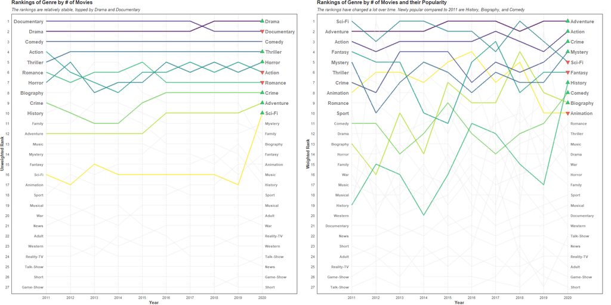

Another approach is to observe the changes in the average/median ratings by genre, comparing 2011 to 2020 numbers.

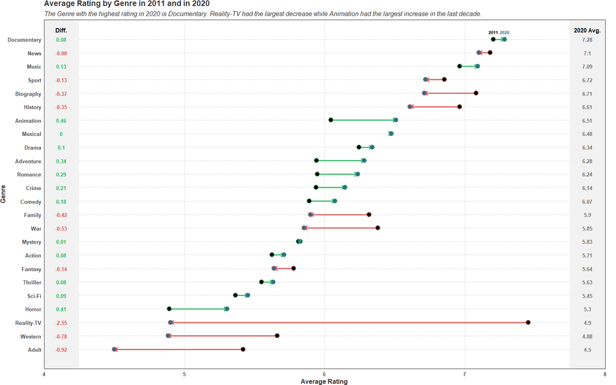